## Session 4: Seasonal ARIMA(p,d,q)x(P,D,Q) Modelling and Forecasting

#### “All models are false, but some are useful.” George Box (1979)

### Aim: Identify (and fit) at least 2 plausible Seasonal ARIMA(p,d,q)(P,D,Q) models for the Atur (No. of unemployed people registered by INEM) time series.

### **Atur:** Spanish Monthly Unemployment Time Series

The data comes from the website of the Ministry of Employment and Social Security of Spain (https://expinterweb.mites.gob.es/series/) in the section Statistics / Labor Market / Registered Labor Movement / Main Series and correspond to the number of individuals registered as unemployed in INEM offices.

### I. Model Identification

#### Exploratory data analysis

Plot the time series

```r
serie=window(ts(read.table("atur.dat")/1000,start=1996,freq=12),start=1996)
print(round(serie,0))
```

```
##       Jan  Feb  Mar  Apr  May  Jun  Jul  Aug  Sep  Oct  Nov  Dec
## 1996 2996 2995 2969 2892 2813 2783 2712 2678 2736 2776 2796 2747
## 1997 2782 2788 2752 2699 2639 2614 2520 2492 2551 2577 2601 2567
## 1998 2577 2553 2524 2443 2370 2332 2250 2235 2256 2268 2270 2233
## 1999 2252 2233 2202 2144 2077 2046 1981 1981 2003 2020 2056 2028
## 2000 2090 2080 2042 1984 1929 1903 1893 1888 1908 1934 1963 1947
## 2001 2017 1993 1981 1910 1898 1843 1836 1879 1889 1941 1986 1989
## 2002 2075 2150 2083 2060 2003 1963 1962 1984 2007 2065 2117 2127
## 2003 2185 2180 2163 2104 2036 2020 1996 2017 2040 2097 2143 2181
## 2004 2233 2219 2182 2162 2091 2054 2014 2050 2051 2076 2121 2113
## 2005 2177 2165 2145 2096 2007 1975 1989 2019 2013 2053 2096 2103
## 2006 2172 2169 2149 2076 2005 1960 1955 1984 1966 1993 2023 2023
## 2007 2083 2075 2059 2023 1973 1966 1970 2028 2017 2049 2094 2130
## 2008 2262 2315 2301 2339 2354 2390 2427 2530 2625 2818 2989 3129
## 2009 3328 3482 3605 3645 3620 3565 3544 3629 3709 3808 3869 3924
## 2010 4048 4131 4167 4142 4066 3982 3909 3970 4018 4086 4110 4100
## 2011 4231 4299 4334 4269 4190 4122 4080 4131 4227 4361 4420 4422
## 2012 4600 4712 4751 4744 4714 4615 4587 4626 4705 4834 4908 4849
## 2013 4981 5040 5035 4989 4891 4764 4699 4699 4724 4811 4809 4701
## 2014 4814 4812 4796 4684 4572 4450 4420 4428 4448 4527 4512 4448
## 2015 4526 4512 4452 4333 4215 4120 4046 4068 4094 4176 4149 4094
## 2016 4151 4153 4095 4011 3891 3767 3683 3697 3720 3765 3790 3703
## 2017 3760 3751 3702 3573 3461 3363 3336 3382 3410 3467 3474 3413
## 2018 3477 3470 3423 3336 3252 3162 3135 3182 3203 3255 3253 3202
## 2019 3286 3289 3255 3164 3079 3016 3011 3066 3080 3178 3198 3164
```

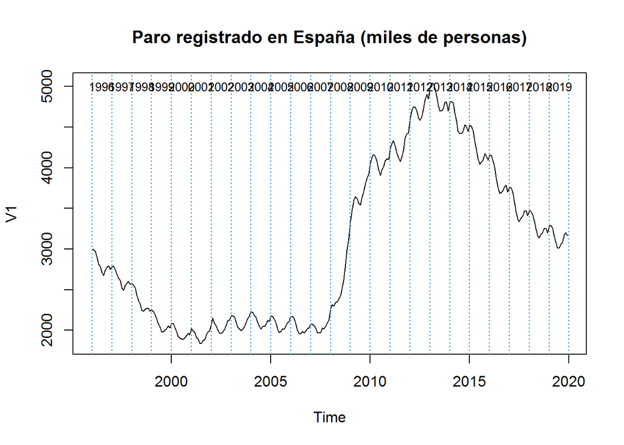

```r
plot(serie,main="Paro registrado en España (miles de personas)")
abline(v=1990:2020,col=4,lty=3)
text(1996:2019+0.5,5000,1996:2019,cex=0.8)
```

Comments? 1996-2000, –2004, —2008, 2010, 2012, 2013-2016

#### Transformation to stationarity

**Is Variance constant?**

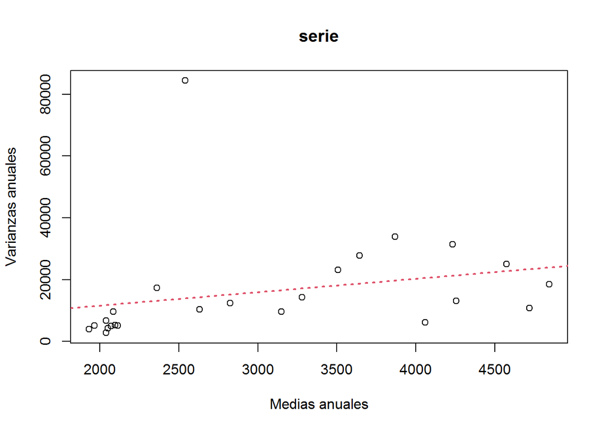

```r
##Plot de medias-varianzas
m=apply(matrix(serie,nr=12),2,mean)
v=apply(matrix(serie,nr=12),2,var)
plot(m,v,xlab="Medias anuales",ylab="Varianzas anuales",main="serie")
abline(lm(v~m),col=2,lty=3,lwd=2)
```

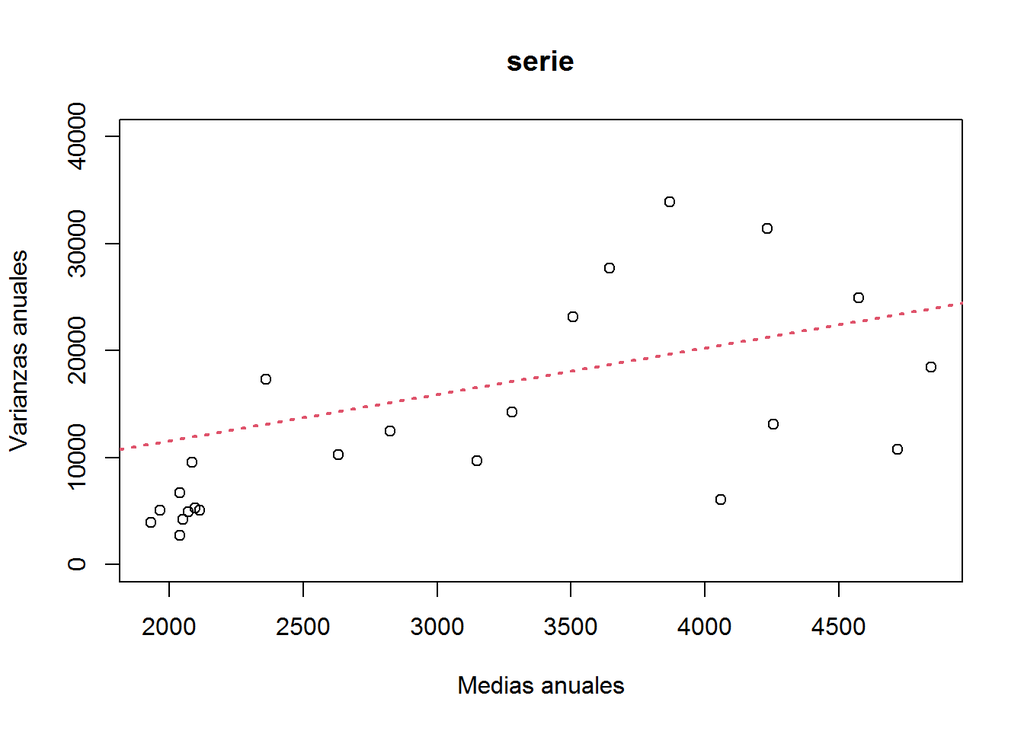

```r
##ZOOM
plot(m,v,xlab="Medias anuales",ylab="Varianzas anuales",main="serie",ylim=c(0,40000))
abline(lm(v~m), col=2, lty=3,lwd=2)
```

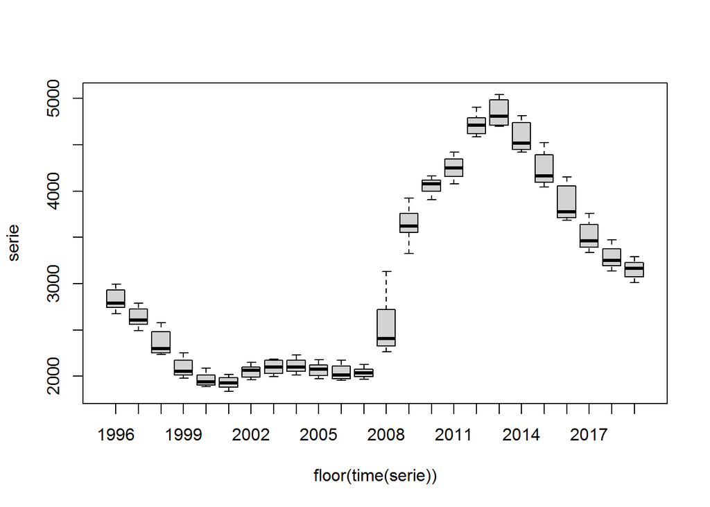

```r
boxplot(serie~floor(time(serie)))
```

Clearly, an increasing variance confirmed. Thus a log transformation applied to stabilize the variance!

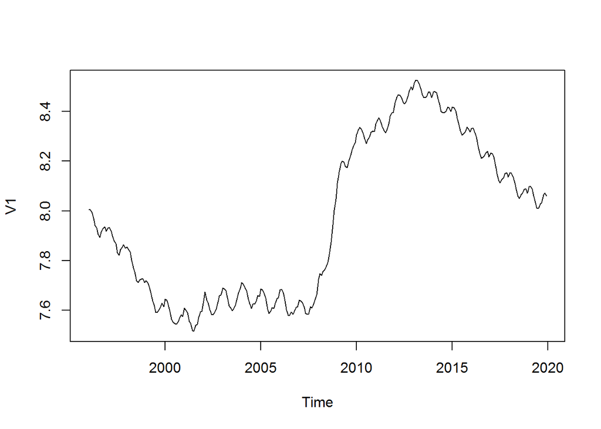

```r
lnserie=log(serie)
plot(lnserie)
```

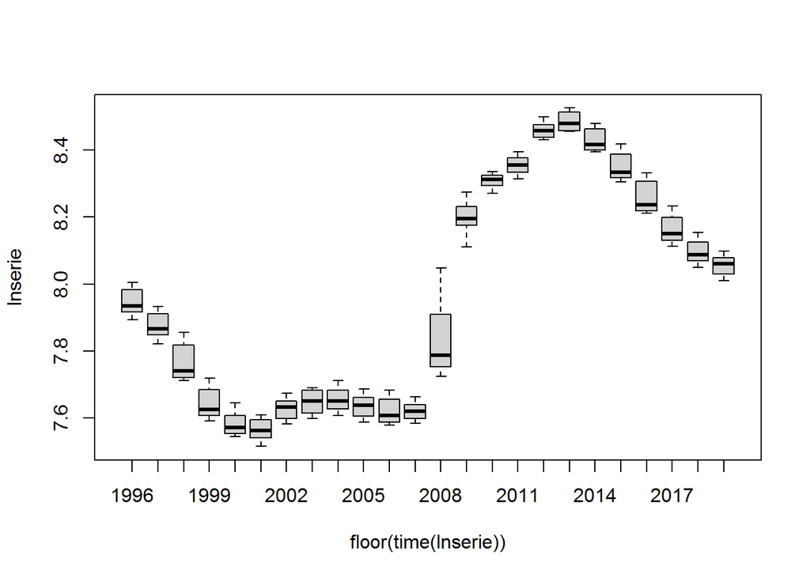

```r
boxplot(lnserie~floor(time(lnserie)))
```

Then, variance seemingly constant!

**Is seasonality present?**

Decomposition plot: For description only

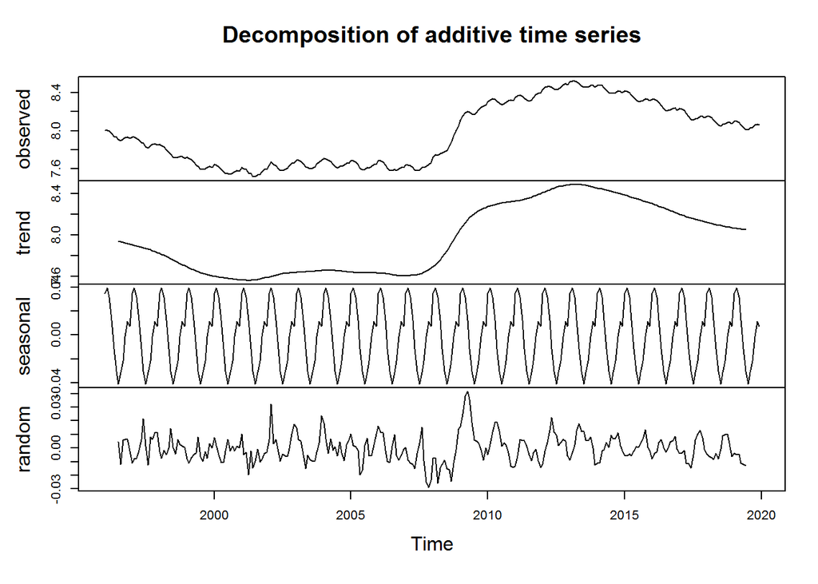

```r
plot(decompose(lnserie))
```

The type of trend and seasonal behavior more clearly seen!

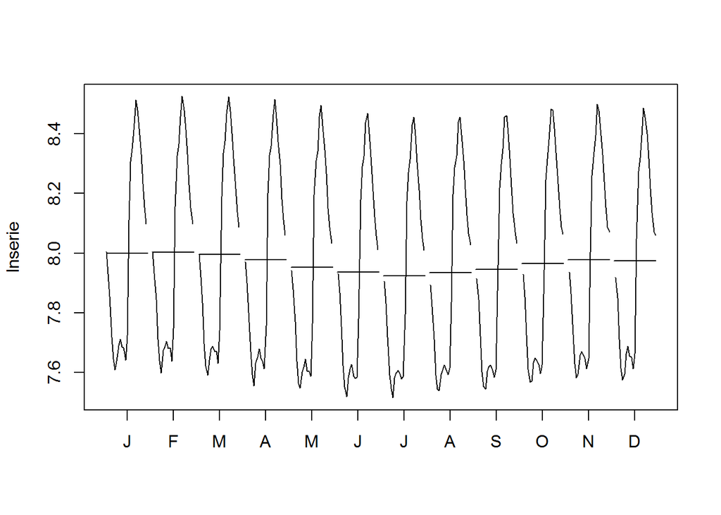

```r
monthplot(lnserie)
```

Thus: seasonality present, with s=12 months. Clearly in summer more employment! Feb and Nov more unemployment!!

#### Eliminate the seasonality applying a seasonal difference $(1-B^{12})\log(Xt)$

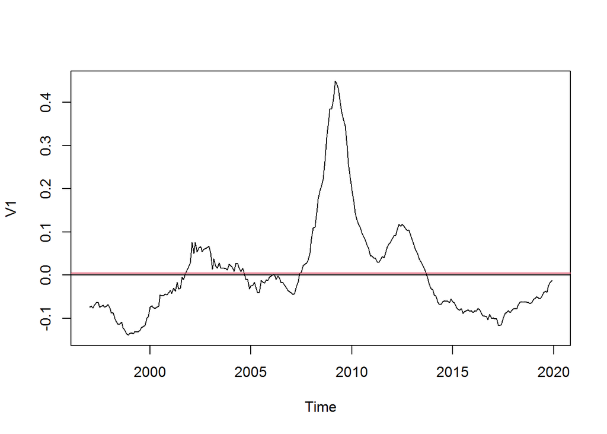

```r
d12lnserie=diff(lnserie,12)
plot(d12lnserie)
abline(h=0)
abline(h=mean(d12lnserie),col=2)
```

**Is the mean constant?**

Apparently not! Thus apply a regular difference

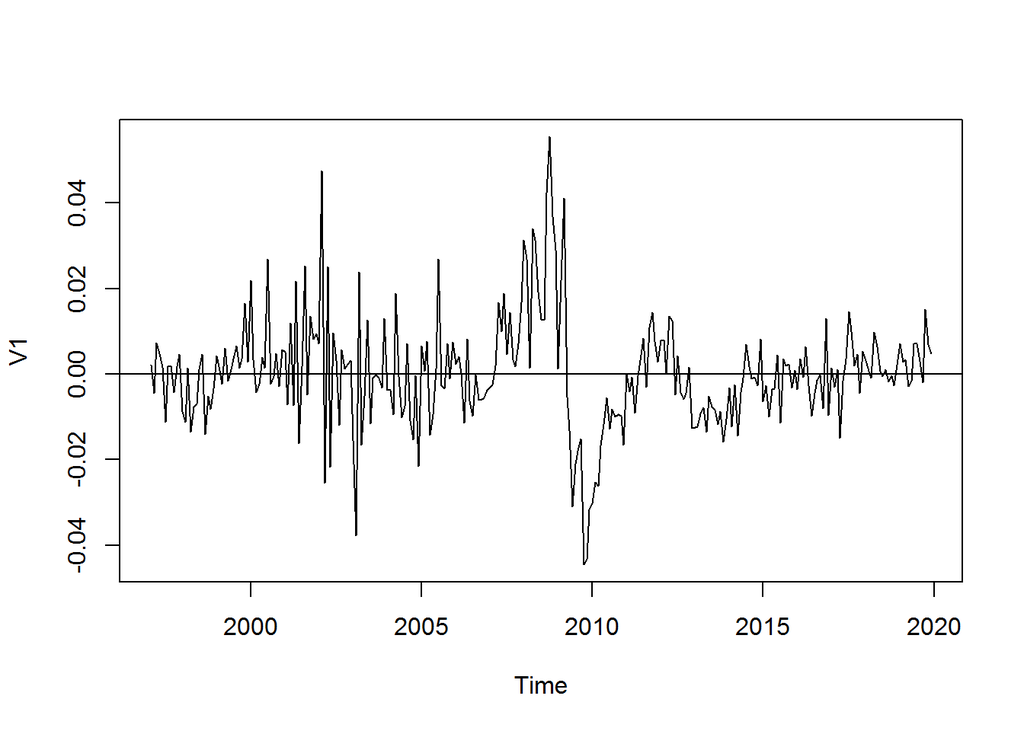

```r
d1d12lnserie=diff(d12lnserie,1)
plot(d1d12lnserie)
abline(h=0)
```

Hmmm, not clear if constant mean. At this point we need to make a decision. We have two options:

1. Consider that d1d12lnserie has already constant mean, or
2. Non-constant mean yet and so we try another regular difference, as follows:

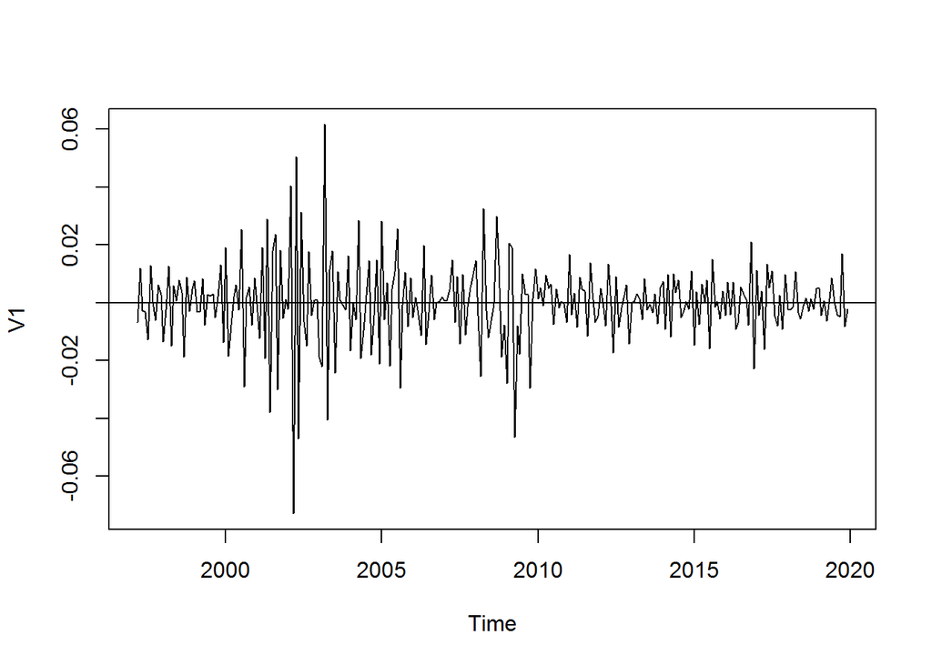

```r
d1d1d12lnserie=diff(d1d12lnserie,1)
plot(d1d1d12lnserie)
abline(h=0)
```

Now, d1d1d12lnserie clearly has a constant mean (Mean =0).

Check for possible overdifferencing: how the variances behave!

```r
var(lnserie)
```

```
##           V1
## V1 0.1057973
```

```r
var(d12lnserie)
```

```
##            V1
## V1 0.01306892
```

```r
var(d1d12lnserie)
```

```
##              V1
## V1 0.0001692097
```

```r
var(d1d1d12lnserie)
```

```
##              V1
## V1 0.0002012453
```

Which series do you choose to fit an ARIMA model? d112lnserie or d1d1d12lnserie? Fit ARIMA models for the chosen time series.

‘Load’ the function ‘validation’: used later

```r
#################Validation#################################
validation=function(model,dades){
  s=frequency(get(model$series))
  resid=model$residuals
  par(mfrow=c(2,2),mar=c(3,3,3,3))
  #Residuals plot
  plot(resid,main="Residuals")
  abline(h=0)
  abline(h=c(-3*sd(resid),3*sd(resid)),lty=3,col=4)
  #Square Root of absolute values of residuals (Homocedasticity)
  scatter.smooth(sqrt(abs(resid)),main="Square Root of Absolute residuals",
                 lpars=list(col=2))

  #Normal plot of residuals
  qqnorm(resid)
  qqline(resid,col=2,lwd=2)

  ##Histogram of residuals with normal curve
  hist(resid,breaks=20,freq=FALSE)
  curve(dnorm(x,mean=mean(resid),sd=sd(resid)),col=2,add=T)


  #ACF & PACF of residuals
  par(mfrow=c(1,2))
  acf(resid,ylim=c(-1,1),lag.max=60,col=c(2,rep(1,s-1)),lwd=1)
  pacf(resid,ylim=c(-1,1),lag.max=60,col=c(rep(1,s-1),2),lwd=1)
  par(mfrow=c(1,1))

  #ACF & PACF of square residuals
  par(mfrow=c(1,2))
  acf(resid^2,ylim=c(-1,1),lag.max=60,col=c(2,rep(1,s-1)),lwd=1)
  pacf(resid^2,ylim=c(-1,1),lag.max=60,col=c(rep(1,s-1),2),lwd=1)
  par(mfrow=c(1,1))

  #Ljung-Box p-values
  par(mar=c(2,2,1,1))
  tsdiag(model,gof.lag=7*s)
  cat("\n--------------------------------------------------------------------\n")
  print(model)

  #Stationary and Invertible
  cat("\nModul of AR Characteristic polynomial Roots: ",
      Mod(polyroot(c(1,-model$model$phi))),"\n")
  cat("\nModul of MA Characteristic polynomial Roots: ",
      Mod(polyroot(c(1,model$model$theta))),"\n")

  #Model expressed as an MA infinity (psi-weights)
  psis=ARMAtoMA(ar=model$model$phi,ma=model$model$theta,lag.max=36)
  names(psis)=paste("psi",1:36)
  cat("\nPsi-weights (MA(inf))\n")
  cat("\n--------------------\n")
  print(psis[1:20])

  #Model expressed as an AR infinity (pi-weights)
  pis=-ARMAtoMA(ar=-model$model$theta,ma=-model$model$phi,lag.max=36)
  names(pis)=paste("pi",1:36)
  cat("\nPi-weights (AR(inf))\n")
  cat("\n--------------------\n")
  print(pis[1:20])

  ## Add here complementary tests (use with caution!)
  ##---------------------------------------------------------
  cat("\nNormality Tests\n")
  cat("\n--------------------\n")

  ##Shapiro-Wilks Normality test
  print(shapiro.test(resid(model)))

  suppressMessages(require(nortest,quietly=TRUE,warn.conflicts=FALSE))
  ##Anderson-Darling test
  print(ad.test(resid(model)))

  suppressMessages(require(tseries,quietly=TRUE,warn.conflicts=FALSE))
  ##Jarque-Bera test
  print(jarque.bera.test(resid(model)))

  cat("\nHomoscedasticity Test\n")
  cat("\n--------------------\n")
  suppressMessages(require(lmtest,quietly=TRUE,warn.conflicts=FALSE))
  ##Breusch-Pagan test
  obs=get(model$series)
  print(bptest(resid(model)~I(obs-resid(model))))

  cat("\nIndependence Tests\n")
  cat("\n--------------------\n")

  ##Durbin-Watson test
  print(dwtest(resid(model)~I(1:length(resid(model)))))

  ##Ljung-Box test
  cat("\nLjung-Box test\n")
  print(t(apply(matrix(c(1:4,(1:4)*s)),1,function(el) {
    te=Box.test(resid(model),type="Ljung-Box",lag=el)
    c(lag=(te$parameter),statistic=te$statistic[[1]],p.value=te$p.value)})))


  #Sample ACF vs. Teoric ACF
  par(mfrow=c(2,2),mar=c(3,3,3,3))
  acf(dades, ylim=c(-1,1) ,lag.max=36,main="Sample ACF")

  plot(ARMAacf(model$model$phi,model$model$theta,lag.max=36),ylim=c(-1,1),
       type="h",xlab="Lag",  ylab="", main="ACF Teoric")
  abline(h=0)

  #Sample PACF vs. Teoric PACF
  pacf(dades, ylim=c(-1,1) ,lag.max=36,main="Sample PACF")

  plot(ARMAacf(model$model$phi,model$model$theta,lag.max=36, pacf=T),ylim=c(-1,1),
       type="h", xlab="Lag", ylab="", main="PACF Teoric")
  abline(h=0)
  par(mfrow=c(1,1))
}
################# Fi Validation #################################
```

### II. Model Fitting and Validation

#### A) Construct feasible models based on d1d12lnserie

P(ACF) of d1d12lnserie and identify possible models

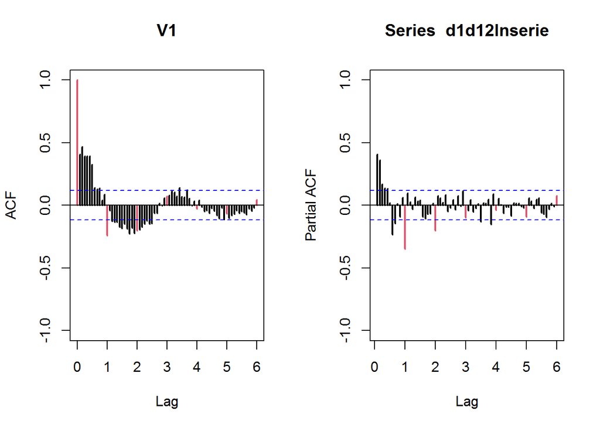

```r
par(mfrow=c(1,2))
acf(d1d12lnserie,ylim=c(-1,1),col=c(2,rep(1,11)),lwd=2,lag.max=72)
pacf(d1d12lnserie,ylim=c(-1,1),col=c(rep(1,11),2),lwd=2,lag.max=72)
```

```r
par(mfrow=c(1,1))
```

In regular part: ARMA(1,1) since both decay; or AR(8).

In seasonal part: Clearly MA(2) or AR(2).

We decide to fit 2 models for d1d12lnserie:

Model 1: SMA(2); ARMA(1,1) regular, and Model 2: SMA(2); AR(8) regular.

#### Model 1

$ARMA(1,0,1)(0,0,2)_{12}$ for stationary d1d12lnserie ($W_t=(1-B)(1-B^{12})\log X_t$)

```r
(mod1=arima(d1d12lnserie,order=c(1,0,1),seasonal=list(order=c(0,0,2),period=12)))
```

```
##
## Call:
## arima(x = d1d12lnserie, order = c(1, 0, 1), seasonal = list(order = c(0, 0,
##     2), period = 12))
##
## Coefficients:
##          ar1      ma1     sma1     sma2  intercept
##       0.9367  -0.6565  -0.5643  -0.0921     0.0002
## s.e.  0.0269   0.0514   0.0620   0.0729     0.0011
##
## sigma^2 estimated as 8.974e-05:  log likelihood = 888,  aic = -1764.01
```

Mean non-significant. Now, fit ARIMA directly to lnserie

$ARIMA(1,1,1)(0,1,2)_{12}$ for Non-Stationary lnserie

```r
(mod1=arima(lnserie,order=c(1,1,1),seasonal=list(order=c(0,1,2),period=12)))
```

```
##
## Call:
## arima(x = lnserie, order = c(1, 1, 1), seasonal = list(order = c(0, 1, 2), period = 12))
##
## Coefficients:
##          ar1      ma1     sma1     sma2
##       0.9369  -0.6565  -0.5646  -0.0922
## s.e.  0.0269   0.0514   0.0620   0.0729
##
## sigma^2 estimated as 8.974e-05:  log likelihood = 888.01,  aic = -1766.02
```

SMA2 coef. non significant; re-do only with without SMA1

```r
(mod1=arima(lnserie,order=c(1,1,1),seasonal=list(order=c(0,1,1),period=12)))
```

```
##
## Call:
## arima(x = lnserie, order = c(1, 1, 1), seasonal = list(order = c(0, 1, 1), period = 12))
##
## Coefficients:
##          ar1      ma1     sma1
##       0.9381  -0.6542  -0.5929
## s.e.  0.0261   0.0505   0.0597
##
## sigma^2 estimated as 9.057e-05:  log likelihood = 887.17,  aic = -1766.34
```

#### Validate Model 1

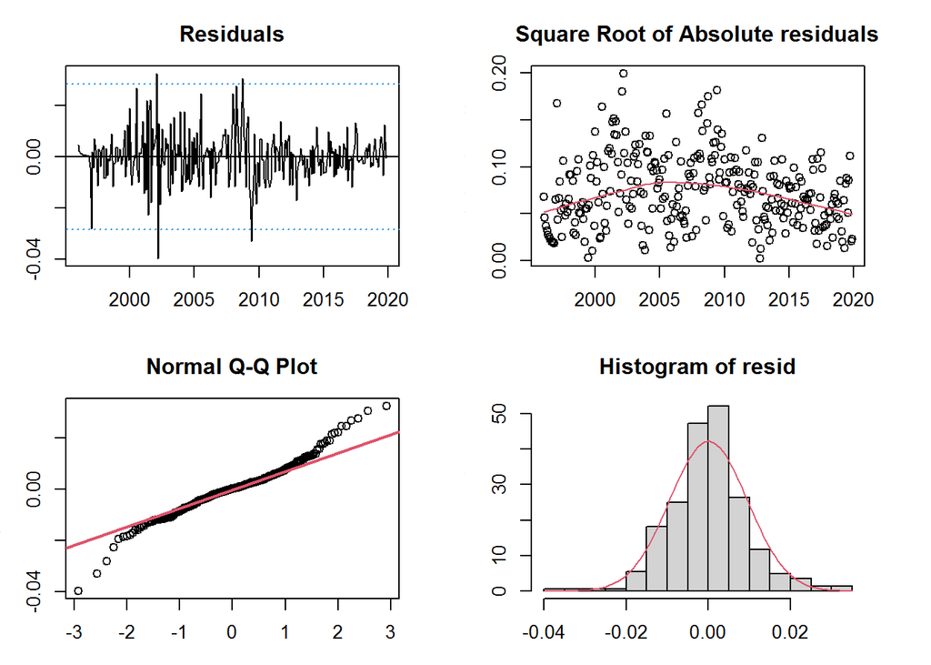

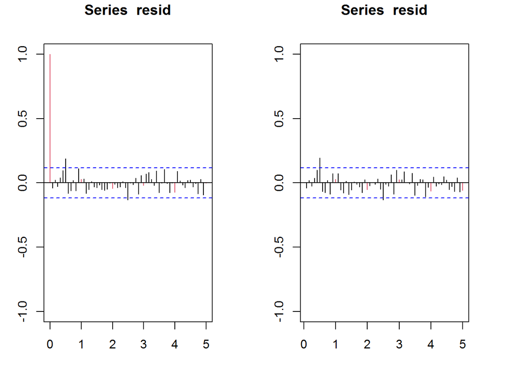

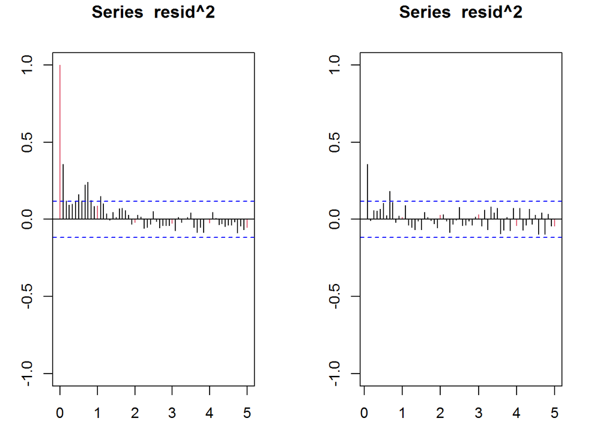

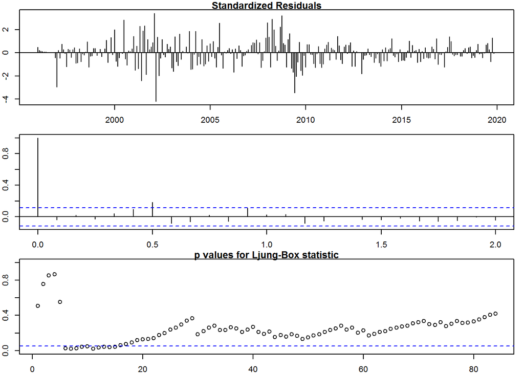

```
##
## --------------------------------------------------------------------
##
## Call:
## arima(x = lnserie, order = c(1, 1, 1), seasonal = list(order = c(0, 1, 1), period = 12))
##
## Coefficients:
##          ar1      ma1     sma1
##       0.9381  -0.6542  -0.5929
## s.e.  0.0261   0.0505   0.0597
##
## sigma^2 estimated as 9.057e-05:  log likelihood = 887.17,  aic = -1766.34
##
## Modul of AR Characteristic polynomial Roots:  1.065996
##
## Modul of MA Characteristic polynomial Roots:  1.044517 1.044517 1.044517 1.044517 1.044517 1.044517 1.044517 1.044517 1.044517 1.044517 1.044517 1.044517 1.528575
##
## Psi-weights (MA(inf))
##
## --------------------
##       psi 1       psi 2       psi 3       psi 4       psi 5       psi 6
##  0.28388614  0.26631078  0.24982350  0.23435696  0.21984794  0.20623718
##       psi 7       psi 8       psi 9      psi 10      psi 11      psi 12
##  0.19346905  0.18149140  0.17025529  0.15971480  0.14982687 -0.45239139
##      psi 13      psi 14      psi 15      psi 16      psi 17      psi 18
## -0.03647855 -0.03422017 -0.03210160 -0.03011420 -0.02824983 -0.02650088
##      psi 19      psi 20
## -0.02486022 -0.02332112
##
## Pi-weights (AR(inf))
##
## --------------------
##         pi 1         pi 2         pi 3         pi 4         pi 5         pi 6
##  0.283886139  0.185719437  0.121498391  0.079484729  0.051999224  0.034018099
##         pi 7         pi 8         pi 9        pi 10        pi 11        pi 12
##  0.022254775  0.014559162  0.009524661  0.006231071  0.004076391 -0.590275703
##        pi 13        pi 14        pi 15        pi 16        pi 17        pi 18
##  0.170072781  0.111262287  0.072788229  0.047618348  0.031152112  0.020379835
##        pi 19        pi 20
##  0.013332569  0.008722219
```

[output cut: 39 more lines]

```
## data:  resid(model) ~ I(1:length(resid(model)))
## DW = 2.0769, p-value = 0.7242
## alternative hypothesis: true autocorrelation is greater than 0
##
##
## Ljung-Box test
##      lag.df  statistic    p.value
## [1,]      1  0.4350951 0.50949937
## [2,]      2  0.5626042 0.75480029
## [3,]      3  0.7776891 0.85479572
## [4,]      4  1.2637189 0.86750040
## [5,]     12 22.4974080 0.03230877
## [6,]     24 29.6635174 0.19615535
## [7,]     36 40.8338531 0.26636776
## [8,]     48 57.4073702 0.16582529
```

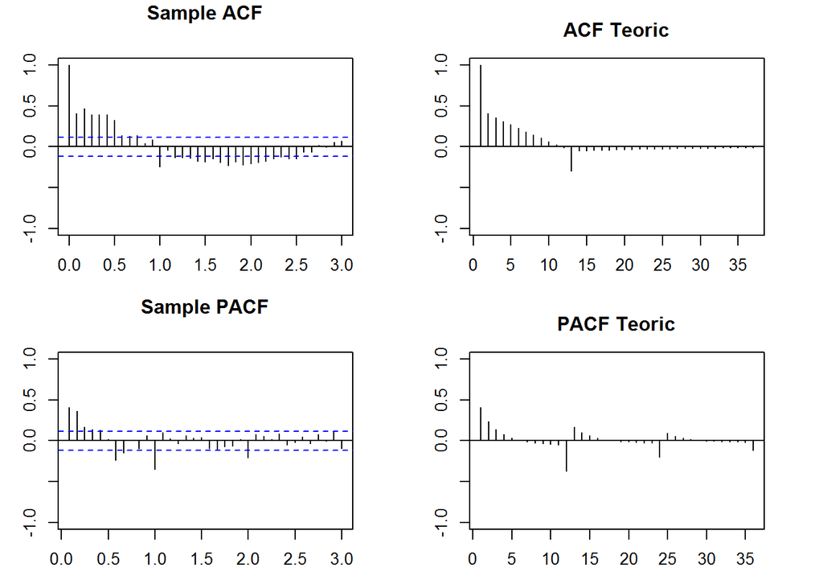

```r
dades=d1d12lnserie
model=mod1
validation(model,dades)
```

#### Model 2

$ARIMA(8,0,0)(0,0,2)_{12}$ for assumed stationary d1d12lnserie ($W_t=(1-B)(1-B^{12})\log X_t$)

```r
(mod2=arima(d1d12lnserie,order=c(8,0,0),seasonal=list(order=c(0,0,2),period=12)))
```

```
##
## Call:
## arima(x = d1d12lnserie, order = c(8, 0, 0), seasonal = list(order = c(0, 0,
##     2), period = 12))
##
## Coefficients:
##          ar1     ar2     ar3     ar4     ar5     ar6      ar7      ar8     sma1
##       0.2083  0.2370  0.1236  0.1277  0.1553  0.1678  -0.1347  -0.1027  -0.5209
## s.e.  0.0614  0.0614  0.0620  0.0611  0.0616  0.0641   0.0610   0.0613   0.0663
##          sma2  intercept
##       -0.0481     0.0002
## s.e.   0.0741     0.0011
##
## sigma^2 estimated as 8.461e-05:  log likelihood = 896.58,  aic = -1769.15
```

Mean non-significant. Now, fit ARIMA directly to lnserie

$ARIMA(8,1,0)(0,1,2)_{12}$ for lnserie

```r
(mod2=arima(lnserie,order=c(8,1,0),seasonal=list(order=c(0,1,2),period=12)))
```

```
##
## Call:
## arima(x = lnserie, order = c(8, 1, 0), seasonal = list(order = c(0, 1, 2), period = 12))
##
## Coefficients:
##          ar1     ar2     ar3     ar4     ar5     ar6      ar7      ar8     sma1
##       0.2086  0.2371  0.1235  0.1276  0.1552  0.1679  -0.1347  -0.1026  -0.5213
## s.e.  0.0614  0.0614  0.0620  0.0611  0.0616  0.0641   0.0610   0.0613   0.0663
##          sma2
##       -0.0482
## s.e.   0.0741
##
## sigma^2 estimated as 8.461e-05:  log likelihood = 896.58,  aic = -1771.16
```

SMA2 coef. non significant; re-do only with without SMA1

```r
(mod2=arima(lnserie,order=c(8,1,0),seasonal=list(order=c(0,1,1),period=12)))
```

```
##
## Call:
## arima(x = lnserie, order = c(8, 1, 0), seasonal = list(order = c(0, 1, 1), period = 12))
##
## Coefficients:
##          ar1     ar2     ar3     ar4     ar5     ar6      ar7      ar8     sma1
##       0.2098  0.2377  0.1249  0.1273  0.1519  0.1785  -0.1347  -0.1088  -0.5373
## s.e.  0.0612  0.0614  0.0618  0.0611  0.0613  0.0621   0.0610   0.0605   0.0627
##
## sigma^2 estimated as 8.482e-05:  log likelihood = 896.37,  aic = -1772.73
```

```r
(mod2b=arima(lnserie,order=c(7,1,0),seasonal=list(order=c(0,1,1),period=12)))
```

```
##
## Call:
## arima(x = lnserie, order = c(7, 1, 0), seasonal = list(order = c(0, 1, 1), period = 12))
##
## Coefficients:
##          ar1     ar2     ar3     ar4     ar5     ar6      ar7     sma1
##       0.2318  0.2179  0.1072  0.1162  0.1374  0.1564  -0.1571  -0.5575
## s.e.  0.0603  0.0612  0.0614  0.0611  0.0612  0.0614   0.0599   0.0623
##
## sigma^2 estimated as 8.576e-05:  log likelihood = 894.76,  aic = -1771.53
```

ar8 non-signicant but do not eliminate because AIC increments!

#### Validate Model 2

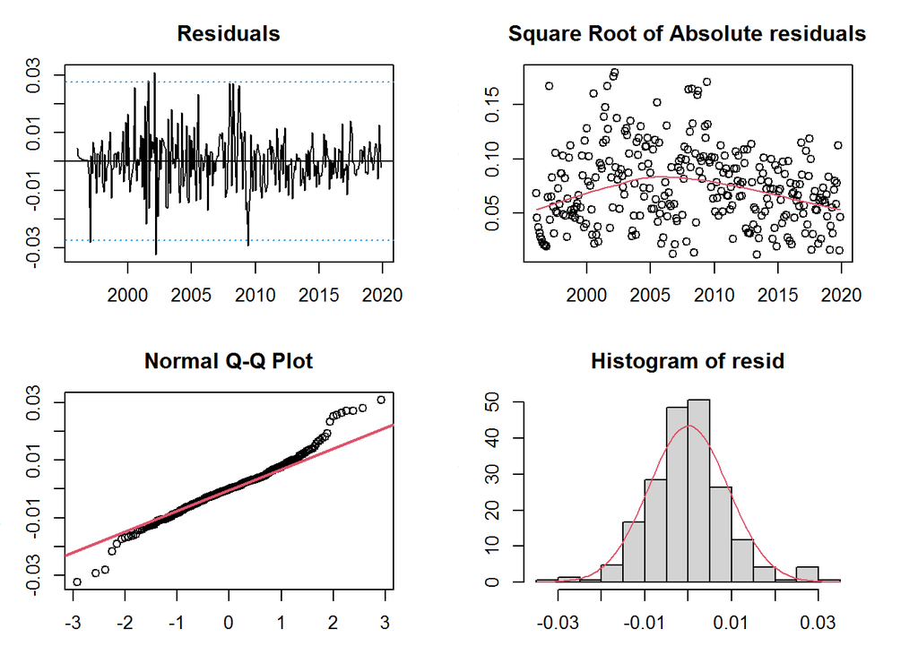

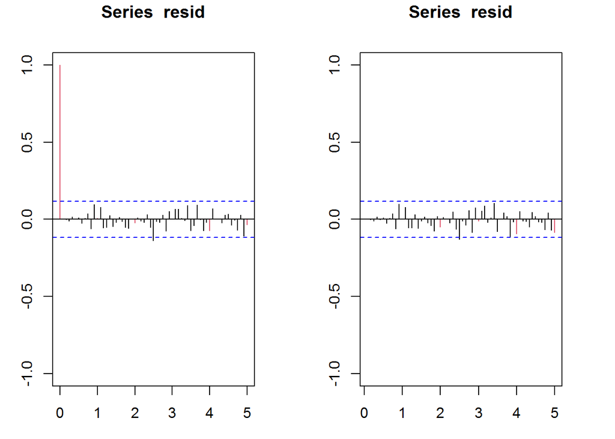

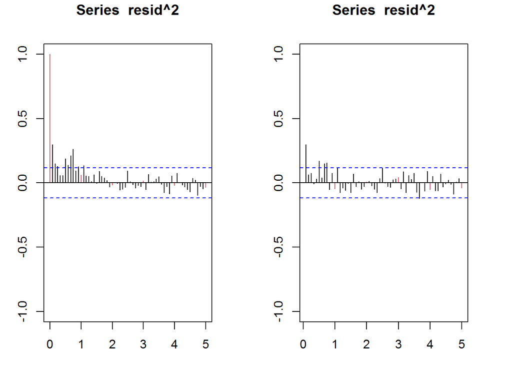

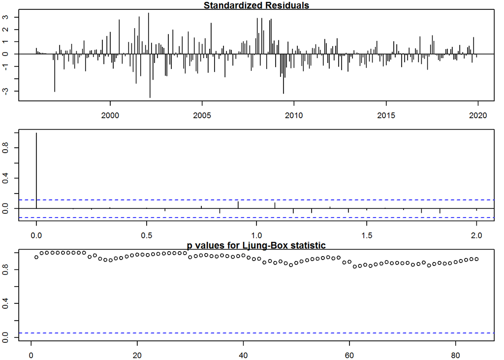

```
##
## --------------------------------------------------------------------
##
## Call:
## arima(x = lnserie, order = c(8, 1, 0), seasonal = list(order = c(0, 1, 1), period = 12))
##
## Coefficients:
##          ar1     ar2     ar3     ar4     ar5     ar6      ar7      ar8     sma1
##       0.2098  0.2377  0.1249  0.1273  0.1519  0.1785  -0.1347  -0.1088  -0.5373
## s.e.  0.0612  0.0614  0.0618  0.0611  0.0613  0.0621   0.0610   0.0605   0.0627
##
## sigma^2 estimated as 8.482e-05:  log likelihood = 896.37,  aic = -1772.73
##
## Modul of AR Characteristic polynomial Roots:  1.192398 1.272136 1.272136 1.154399 1.304157 1.629132 1.192398 1.629132
##
## Modul of MA Characteristic polynomial Roots:  1.053137 1.053137 1.053137 1.053137 1.053137 1.053137 1.053137 1.053137 1.053137 1.053137 1.053137 1.053137
##
## Psi-weights (MA(inf))
##
## --------------------
##       psi 1       psi 2       psi 3       psi 4       psi 5       psi 6
##  0.20979109  0.28174486  0.23390675  0.26953445  0.32594423  0.40787480
##       psi 7       psi 8       psi 9      psi 10      psi 11      psi 12
##  0.17205572  0.15687655  0.18817571  0.18564490  0.18356177 -0.38542739
##      psi 13      psi 14      psi 15      psi 16      psi 17      psi 18
## -0.02592717 -0.06146305 -0.02190441 -0.05289329 -0.09853474 -0.16144513
##      psi 19      psi 20
## -0.04870947 -0.03652444
##
## Pi-weights (AR(inf))
##
## --------------------
##        pi 1        pi 2        pi 3        pi 4        pi 5        pi 6
##  0.20979109  0.23773256  0.12492502  0.12727482  0.15189295  0.17847188
##        pi 7        pi 8        pi 9       pi 10       pi 11       pi 12
## -0.13467924 -0.10876568  0.00000000  0.00000000  0.00000000 -0.53725935
##       pi 13       pi 14       pi 15       pi 16       pi 17       pi 18
##  0.11271222  0.12772404  0.06711713  0.06837958  0.08160591  0.09588568
##       pi 19       pi 20
## -0.07235768 -0.05843538
```

[output cut: 39 more lines]

```
## data:  resid(model) ~ I(1:length(resid(model)))
## DW = 1.9916, p-value = 0.4479
## alternative hypothesis: true autocorrelation is greater than 0
##
##
## Ljung-Box test
##      lag.df    statistic   p.value
## [1,]      1  0.004624095 0.9457851
## [2,]      2  0.005641390 0.9971833
## [3,]      3  0.032944008 0.9984253
## [4,]      4  0.098007965 0.9988378
## [5,]     12  4.607211649 0.9698300
## [6,]     24 11.387541602 0.9859693
## [7,]     36 22.010052587 0.9676900
## [8,]     48 36.923762444 0.8773599
```

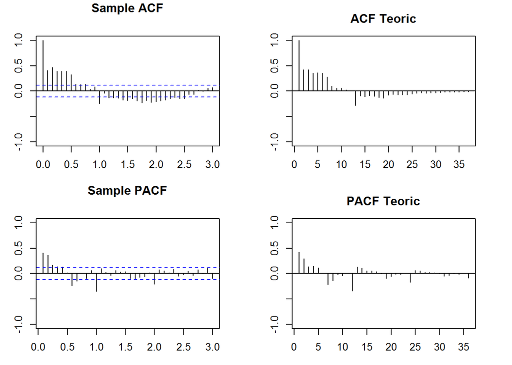

```r
dades=d1d12lnserie
model=mod2
validation(model,dades)
```

### B) Alternative Model 3 for series d1d1d12lnserie with constant mean( = 0)

P(ACF) for series d1d1d12lnserie

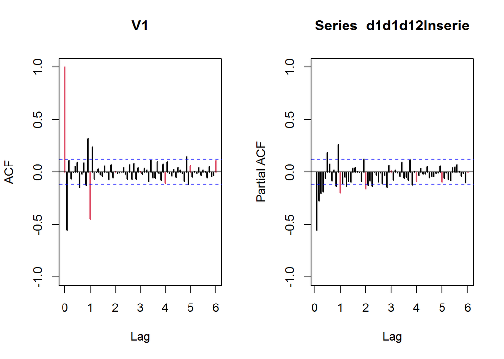

```r
par(mfrow=c(1,2))
acf(d1d1d12lnserie,ylim=c(-1,1),col=c(2,rep(1,11)),lwd=2,lag.max=72)
pacf(d1d1d12lnserie,ylim=c(-1,1),col=c(rep(1,11),2),lwd=2,lag.max=72)
```

```r
par(mfrow=c(1,1))
```

Clealy an SMA(1) and MA(1)

#### Model 3 for d1d1d12lnserie: ARIMA(0,2,1)x(0,1,1)12 (the so-called airline model)

$ARIMA(0,2,1)(0,1,1)_{12}$ for NON-Stationary lnserie

```r
(mod3=arima(lnserie,order=c(0,2,1),seasonal=list(order=c(0,1,1),period=12)))
```

```
##
## Call:
## arima(x = lnserie, order = c(0, 2, 1), seasonal = list(order = c(0, 1, 1), period = 12))
##
## Coefficients:
##           ma1     sma1
##       -0.6916  -0.6002
## s.e.   0.0411   0.0597
##
## sigma^2 estimated as 9.587e-05:  log likelihood = 872.92,  aic = -1739.83
```

#### Validate model 3

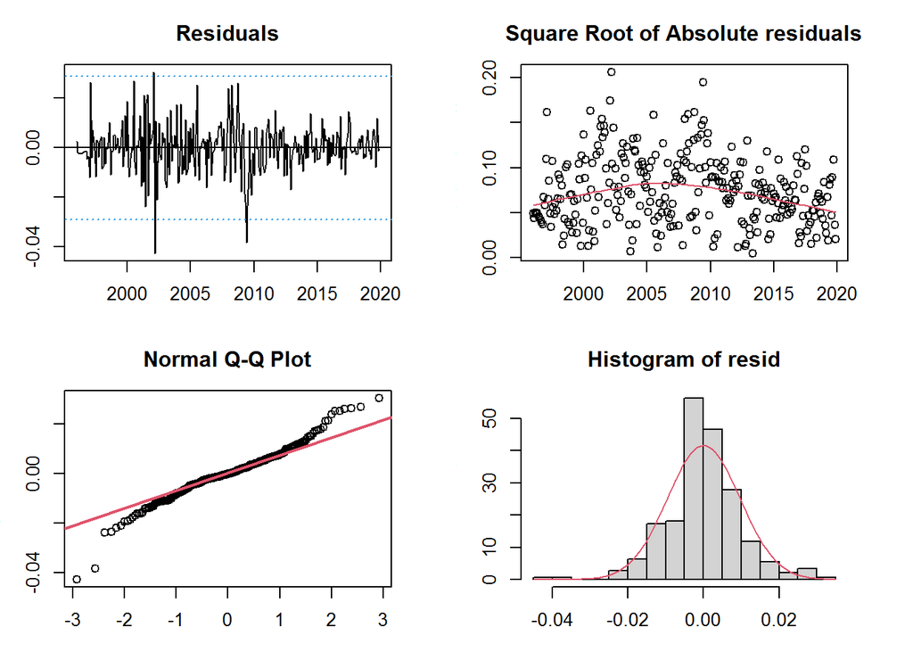

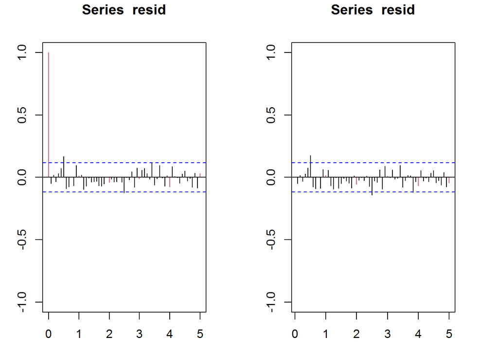

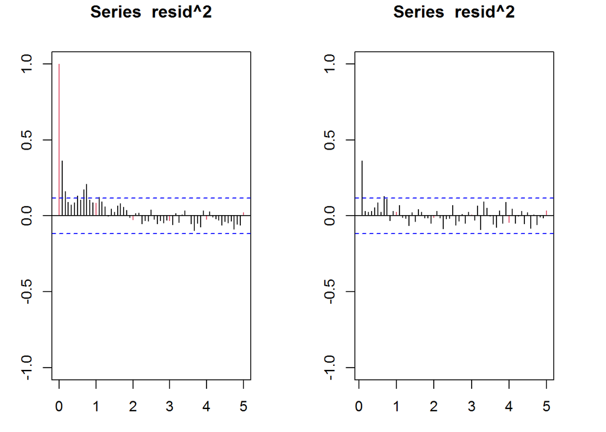

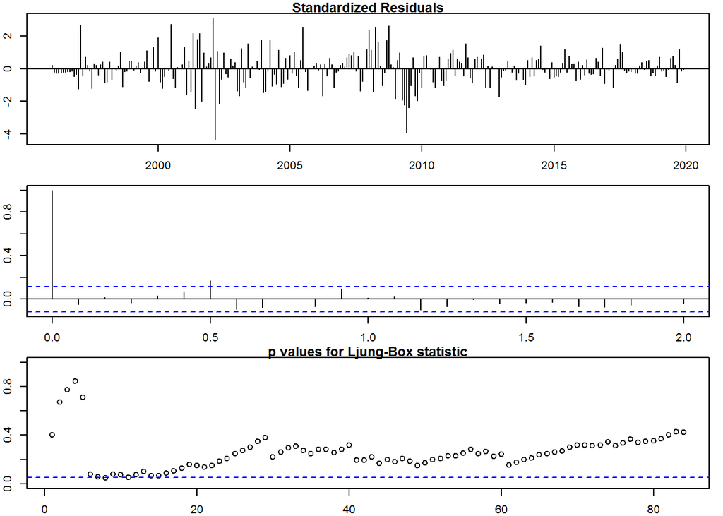

```
##
## --------------------------------------------------------------------
##
## Call:
## arima(x = lnserie, order = c(0, 2, 1), seasonal = list(order = c(0, 1, 1), period = 12))
##
## Coefficients:
##           ma1     sma1
##       -0.6916  -0.6002
## s.e.   0.0411   0.0597
##
## sigma^2 estimated as 9.587e-05:  log likelihood = 872.92,  aic = -1739.83
##
## Modul of AR Characteristic polynomial Roots:
##
## Modul of MA Characteristic polynomial Roots:  1.043465 1.043465 1.043465 1.043465 1.043465 1.043465 1.043465 1.043465 1.043465 1.043465 1.043465 1.043465 1.445836
##
## Psi-weights (MA(inf))
##
## --------------------
##      psi 1      psi 2      psi 3      psi 4      psi 5      psi 6      psi 7
## -0.6916412  0.0000000  0.0000000  0.0000000  0.0000000  0.0000000  0.0000000
##      psi 8      psi 9     psi 10     psi 11     psi 12     psi 13     psi 14
##  0.0000000  0.0000000  0.0000000  0.0000000 -0.6001573  0.4150935  0.0000000
##     psi 15     psi 16     psi 17     psi 18     psi 19     psi 20
##  0.0000000  0.0000000  0.0000000  0.0000000  0.0000000  0.0000000
##
## Pi-weights (AR(inf))
##
## --------------------
##        pi 1        pi 2        pi 3        pi 4        pi 5        pi 6
## -0.69164122 -0.47836758 -0.33085874 -0.22883554 -0.15827209 -0.10946750
##        pi 7        pi 8        pi 9       pi 10       pi 11       pi 12
## -0.07571224 -0.05236570 -0.03621828 -0.02505006 -0.01732565 -0.61214044
##       pi 13       pi 14       pi 15       pi 16       pi 17       pi 18
## -0.42338156 -0.29282814 -0.20253201 -0.14007949 -0.09688475 -0.06700949
##       pi 19       pi 20
## -0.04634652 -0.03205517
##
## Normality Tests
```

[output cut: 37 more lines]

```
## data:  resid(model) ~ I(1:length(resid(model)))
## DW = 2.0984, p-value = 0.7818
## alternative hypothesis: true autocorrelation is greater than 0
##
##
## Ljung-Box test
##      lag.df  statistic    p.value
## [1,]      1  0.7008766 0.40248931
## [2,]      2  0.7958576 0.67170986
## [3,]      3  1.1171354 0.77293921
## [4,]      4  1.4004723 0.84411293
## [5,]     12 19.6940162 0.07310008
## [6,]     24 29.3917114 0.20573656
## [7,]     36 40.3336559 0.28451679
## [8,]     48 56.6159768 0.18437953
```

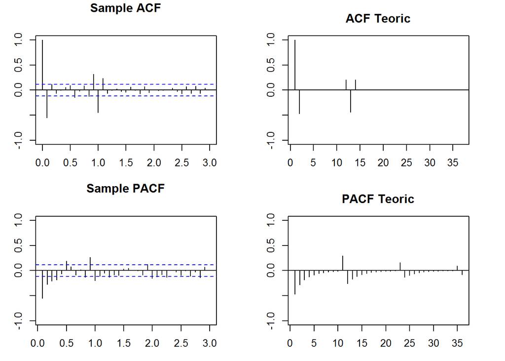

```r
dades=d1d1d12lnserie
model=mod3
validation(model,dades)
```

Similar validation “behavior” to model 1

### III. Forecasting

#### Forecasting: Model 1

**Is model 1 stable?**

```r
########### Model stability (without constant!!!) ###############

ultim=c(2018,12)
pdq=c(1,1,1)
PDQ=c(0,1,1)

serie2=window(serie,end=ultim)
lnserie2=log(serie2)
serie1=window(serie,end=ultim+c(1,0))
lnserie1=log(serie1)

(modA=arima(lnserie1,order=pdq,seasonal=list(order=PDQ,period=12)))
```

```
##
## Call:
## arima(x = lnserie1, order = pdq, seasonal = list(order = PDQ, period = 12))
##
## Coefficients:
##          ar1      ma1     sma1
##       0.9381  -0.6542  -0.5929
## s.e.  0.0261   0.0505   0.0597
##
## sigma^2 estimated as 9.057e-05:  log likelihood = 887.17,  aic = -1766.34
```

```r
(modB=arima(lnserie2,order=pdq,seasonal=list(order=PDQ,period=12)))
```

```
##
## Call:
## arima(x = lnserie2, order = pdq, seasonal = list(order = PDQ, period = 12))
##
## Coefficients:
##          ar1      ma1     sma1
##       0.9374  -0.6526  -0.5953
## s.e.  0.0267   0.0518   0.0607
##
## sigma^2 estimated as 9.32e-05:  log likelihood = 844.54,  aic = -1681.08
```

#### Thus stable (significance, sign and magnitud)

#### Out-of-sample prediction

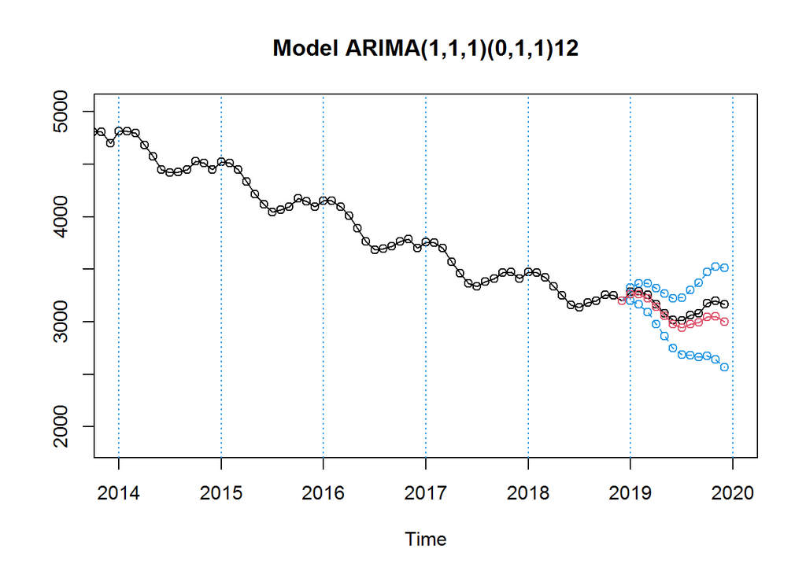

```r
pred=predict(modB,n.ahead=12)
pr<-ts(c(tail(lnserie2,1),pred$pred),start=ultim,freq=12)
se<-ts(c(0,pred$se),start=ultim,freq=12)

#Intervals
tl<-ts(exp(pr-1.96*se),start=ultim,freq=12)
tu<-ts(exp(pr+1.96*se),start=ultim,freq=12)
pr<-ts(exp(pr),start=ultim,freq=12)


ts.plot(serie,tl,tu,pr,lty=c(1,2,2,1),col=c(1,4,4,2),xlim=c(2014,2020),type="o",main=paste("Model ARIMA(",paste(pdq,collapse=","),")(",paste(PDQ,collapse=","),")12",sep=""))
abline(v=2014:2020,lty=3,col=4)
```

Compute metrics for forecasting capability

```r
(previs=window(cbind(tl,pr,tu,serie,error=round(serie-pr,3)),start=ultim))
```

```
##                tl       pr       tu    serie   error
## Dec 2018 3202.297 3202.297 3202.297 3202.297   0.000
## Jan 2019 3201.182 3262.332 3324.650 3285.761  23.429
## Feb 2019 3163.184 3262.150 3364.212 3289.040  26.890
## Mar 2019 3090.204 3224.561 3364.760 3255.084  30.523
## Apr 2019 2975.754 3142.544 3318.683 3163.566  21.022
## May 2019 2861.512 3059.125 3270.383 3079.491  20.366
## Jun 2019 2748.796 2975.543 3220.994 3015.686  40.143
## Jul 2019 2683.992 2942.482 3225.866 3011.433  68.951
## Aug 2019 2679.623 2975.653 3304.387 3065.804  90.151
## Sep 2019 2664.456 2997.383 3371.910 3079.711  82.328
## Oct 2019 2674.327 3047.940 3473.748 3177.659 129.719
## Nov 2019 2643.012 3051.883 3524.006 3198.184 146.301
## Dec 2019 2565.959 3001.938 3511.994 3163.605 161.667
```

```r
obs=window(serie,start=ultim)

mod.RMSE1=sqrt(sum((obs-pr)^2)/12)
mod.MAE1=sum(abs(obs-pr))/12
mod.RMSPE1=sqrt(sum(((obs-pr)/obs)^2)/12)
mod.MAPE1=sum(abs(obs-pr)/obs)/12

data.frame("RMSE"=mod.RMSE1,"MAE"=mod.MAE1,"RMSPE"=mod.RMSPE1,"MAPE"=mod.MAPE1)
```

```
##       RMSE      MAE      RMSPE       MAPE
## 1 85.97406 70.12423 0.02730192 0.02232973
```

```r
mCI1=mean(tu-tl)

cat("\nMean Length CI: ",mCI1)
```

```
##
## Mean Length CI:  486.4301
```

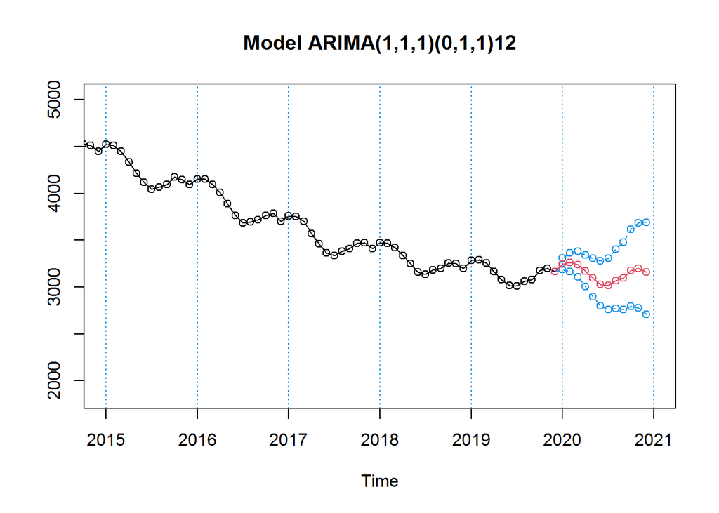

```r
##### Long-term predictions with the complete model ######

pred=predict(modA,n.ahead=12)
pr<-ts(c(tail(lnserie1,1),pred$pred),start=ultim+c(1,0),freq=12)
se<-ts(c(0,pred$se),start=ultim+c(1,0),freq=12)

#Intervals
tl1<-ts(exp(pr-1.96*se),start=ultim+c(1,0),freq=12)
tu1<-ts(exp(pr+1.96*se),start=ultim+c(1,0),freq=12)
pr1<-ts(exp(pr),start=ultim+c(1,0),freq=12)

ts.plot(serie,tl1,tu1,pr1,lty=c(1,2,2,1),col=c(1,4,4,2),xlim=c(2015,2021),type="o",main=paste("Model ARIMA(",paste(pdq,collapse=","),")(",paste(PDQ,collapse=","),")12",sep=""))
abline(v=2015:2021,lty=3,col=4)
```

```r
(previs1=window(cbind(tl1,pr1,tu1),start=ultim+c(1,0)))
```

```
##               tl1      pr1      tu1
## Dec 2019 3163.605 3163.605 3163.605
## Jan 2020 3188.206 3248.233 3309.389
## Feb 2020 3166.840 3264.443 3365.055
## Mar 2020 3109.269 3242.389 3381.208
## Apr 2020 3003.454 3169.181 3344.053
## May 2020 2899.682 3096.783 3307.282
## Jun 2020 2803.674 3031.285 3277.374
## Jul 2020 2758.268 3019.681 3305.869
## Aug 2020 2770.556 3071.742 3405.669
## Sep 2020 2760.446 3099.845 3480.974
## Oct 2020 2795.405 3179.674 3616.766
## Nov 2020 2776.160 3198.744 3685.654
## Dec 2020 2708.472 3161.290 3689.814
```

#### Forecasting: Model 2

**Is model 2 stable?**

```r
###########  Model stability (without constant!!!) ###############
ultim=c(2018,12)
pdq=c(8,1,0)
PDQ=c(0,1,1)

serie2=window(serie,end=ultim)
lnserie2=log(serie2)
serie1=window(serie,end=ultim+c(1,0))
lnserie1=log(serie1)

(modA=arima(lnserie1,order=pdq,seasonal=list(order=PDQ,period=12)))
```

```
##
## Call:
## arima(x = lnserie1, order = pdq, seasonal = list(order = PDQ, period = 12))
##
## Coefficients:
##          ar1     ar2     ar3     ar4     ar5     ar6      ar7      ar8     sma1
##       0.2098  0.2377  0.1249  0.1273  0.1519  0.1785  -0.1347  -0.1088  -0.5373
## s.e.  0.0612  0.0614  0.0618  0.0611  0.0613  0.0621   0.0610   0.0605   0.0627
##
## sigma^2 estimated as 8.482e-05:  log likelihood = 896.37,  aic = -1772.73
```

```r
(modB=arima(lnserie2,order=pdq,seasonal=list(order=PDQ,period=12)))
```

```
##
## Call:
## arima(x = lnserie2, order = pdq, seasonal = list(order = PDQ, period = 12))
##
## Coefficients:
##          ar1     ar2     ar3     ar4     ar5     ar6      ar7      ar8     sma1
##       0.2117  0.2392  0.1234  0.1258  0.1486  0.1779  -0.1355  -0.1057  -0.5381
## s.e.  0.0627  0.0629  0.0631  0.0622  0.0625  0.0633   0.0621   0.0618   0.0646
##
## sigma^2 estimated as 8.74e-05:  log likelihood = 853.2,  aic = -1686.39
```

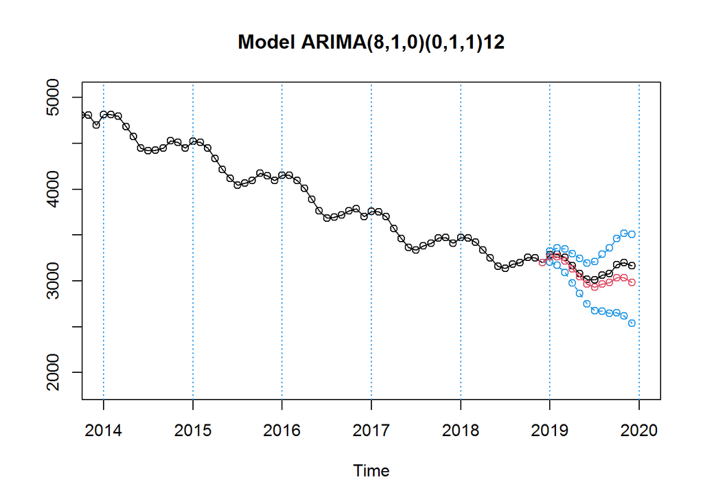

```r
pred=predict(modB,n.ahead=12)
pr<-ts(c(tail(lnserie2,1),pred$pred),start=ultim,freq=12)
se<-ts(c(0,pred$se),start=ultim,freq=12)

#Intervals
tl<-ts(exp(pr-1.96*se),start=ultim,freq=12)
tu<-ts(exp(pr+1.96*se),start=ultim,freq=12)
pr<-ts(exp(pr),start=ultim,freq=12)


ts.plot(serie,tl,tu,pr,lty=c(1,2,2,1),col=c(1,4,4,2),xlim=c(2014,2020),type="o",main=paste("Model ARIMA(",paste(pdq,collapse=","),")(",paste(PDQ,collapse=","),")12",sep=""))
abline(v=2014:2020,lty=3,col=4)
```

```r
(previs=window(cbind(tl,pr,tu,serie,error=round(serie-pr,3)),start=ultim))
```

```
##                tl       pr       tu    serie   error
## Dec 2018 3202.297 3202.297 3202.297 3202.297   0.000
## Jan 2019 3203.874 3263.122 3323.466 3285.761  22.639
## Feb 2019 3169.898 3262.477 3357.761 3289.040  26.563
## Mar 2019 3092.713 3218.115 3348.602 3255.084  36.969
## Apr 2019 2976.247 3131.469 3294.786 3163.566  32.097
## May 2019 2861.250 3046.282 3243.280 3079.491  33.209
## Jun 2019 2747.475 2963.680 3196.899 3015.686  52.006
## Jul 2019 2677.051 2931.424 3209.966 3011.433  80.009
## Aug 2019 2668.565 2964.549 3293.361 3065.804 101.255
## Sep 2019 2648.574 2983.816 3361.490 3079.711  95.895
## Oct 2019 2654.340 3032.484 3464.500 3177.659 145.175
## Nov 2019 2619.853 3035.495 3517.080 3198.184 162.689
## Dec 2019 2540.101 2985.091 3508.035 3163.605 178.514
```

```r
obs=window(serie,start=ultim)

mod.RMSE2=sqrt(sum((obs-pr)^2)/12)
mod.MAE2=sum(abs(obs-pr))/12
mod.RMSPE2=sqrt(sum(((obs-pr)/obs)^2)/12)
mod.MAPE2=sum(abs(obs-pr)/obs)/12

data.frame("RMSE"=mod.RMSE2,"MAE"=mod.MAE2,"RMSPE"=mod.RMSPE2,"MAPE"=mod.MAPE2)
```

```
##       RMSE      MAE      RMSPE       MAPE
## 1 96.90336 80.58499 0.03079975 0.02568454
```

```r
mCI2=mean(tu-tl)

cat("\nMean Length CI: ",mCI2)
```

```
##
## Mean Length CI:  481.4833
```

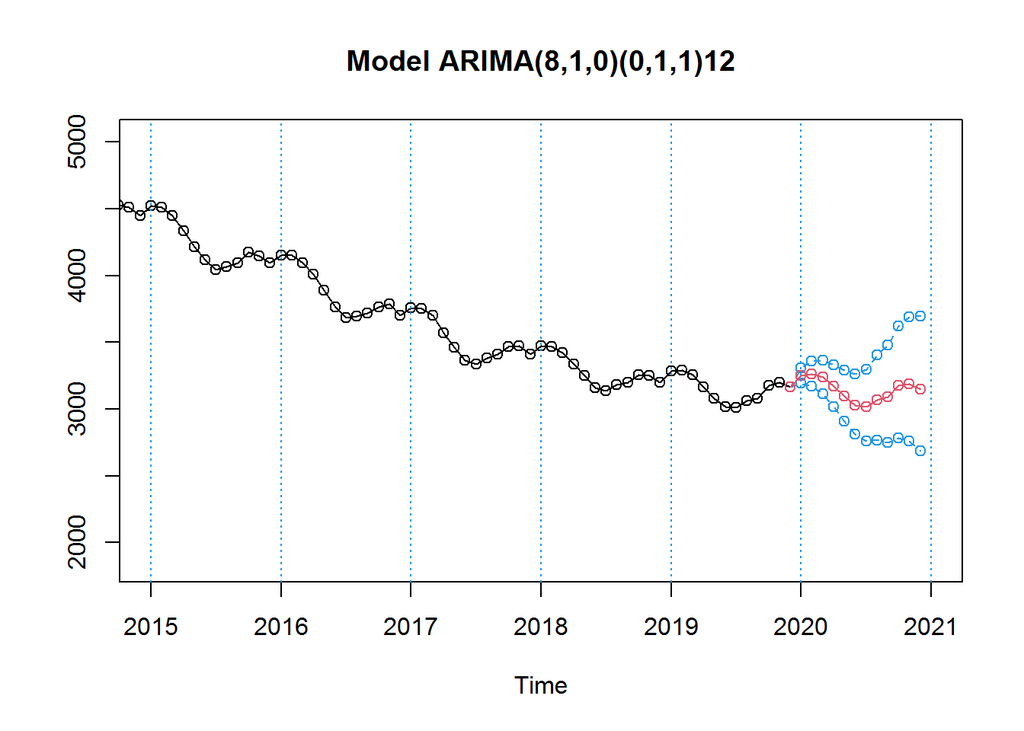

```r
##### Long-term predictions with the complete model ######


pred=predict(modA,n.ahead=12)
pr<-ts(c(tail(lnserie1,1),pred$pred),start=ultim+c(1,0),freq=12)
se<-ts(c(0,pred$se),start=ultim+c(1,0),freq=12)

#Intervals
tl1<-ts(exp(pr-1.96*se),start=ultim+c(1,0),freq=12)
tu1<-ts(exp(pr+1.96*se),start=ultim+c(1,0),freq=12)
pr1<-ts(exp(pr),start=ultim+c(1,0),freq=12)

ts.plot(serie,tl1,tu1,pr1,lty=c(1,2,2,1),col=c(1,4,4,2),xlim=c(2015,2021),type="o",main=paste("Model ARIMA(",paste(pdq,collapse=","),")(",paste(PDQ,collapse=","),")12",sep=""))
abline(v=2015:2021,lty=3,col=4)
```

```r
(previs2=window(cbind(tl1,pr1,tu1),start=ultim+c(1,0)))
```

```
##               tl1      pr1      tu1
## Dec 2019 3163.605 3163.605 3163.605
## Jan 2020 3192.966 3251.125 3310.344
## Feb 2020 3172.665 3263.840 3357.635
## Mar 2020 3114.034 3238.154 3367.222
## Apr 2020 3015.761 3170.309 3332.776
## May 2020 2911.386 3096.365 3293.095
## Jun 2020 2811.423 3028.861 3263.115
## Jul 2020 2759.879 3017.700 3299.606
## Aug 2020 2767.137 3068.964 3403.713
## Sep 2020 2751.895 3094.453 3479.652
## Oct 2020 2785.067 3175.326 3620.270
## Nov 2020 2760.523 3191.374 3689.471
## Dec 2020 2687.549 3150.829 3693.970
```